# Programming with Python

## File Handling

#### Instructor: Bishal Rijal

# File Handling in Python

Python provides basic functions and methods necessary to manipulate files by default.

You can do your most of the file manipulation using a **file** object.

## The open Function

Before you can read or write a file, you have to open it using Python's built-in open() function.

This function creates a file object which would be utilized to call other support methods associated with it.

Syntax:  
file f = open(file_name [, access_mode][, buffering])  
Where

file_name is the name of the file that you want to access.

access_mode determines the mode in which the file has to be opened ie. read, write append etc. This is an optional parameter and the default file access mode is read (r)

buffering: If the buffering value is set to 0, no buffering will take place. If the buffering value is 1, line buffering will be performed while accessing a file. If you specify the buffering value as an integer greater than 1, then buffering action will be performed with the indicated buffer size. If negative, the buffer size is the system default(default behavior).

# Different modes of opening a file:

[figure not shown]

# Different modes of opening a file:

[figure not shown]

## 'file' object atrribute

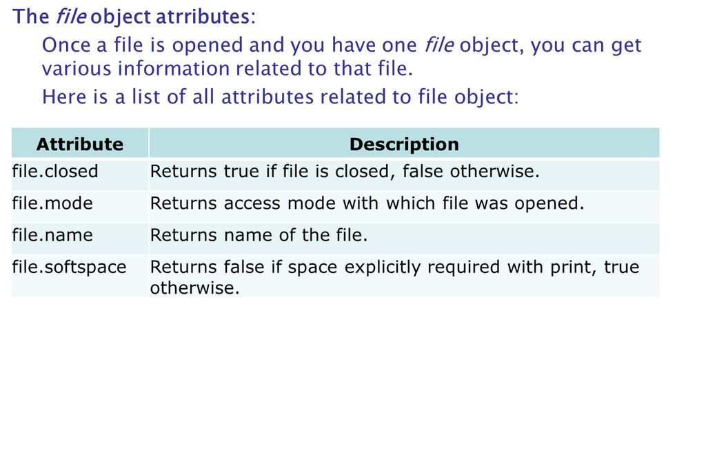

## Reading files

s= file.read(number_of_characters)  
ss = file.readline(number_of_characters)  
list_of_strings = the_file.readlines()

## Writing files

the_file.write(string)  
the_file.writelines(list_of_strings)

```python
f=open("newfile.txt","r")
f
```

```
<_io.TextIOWrapper name='newfile.txt' mode='r' encoding='cp1252'>
```

```python
f.read()
```

```
'Hello Again'
```

```python
f.name
```

```
'newfile.txt'
```

```python
f.closed
```

```
False
```

```python
f.mode
```

```
'r'
```

```python
f.write("Hello again!!!")
```

```
---------------------------------------------------------------------------
UnsupportedOperation                      Traceback (most recent call last)
Cell In[47], line 1
----> 1 f.write("Hello again!!!")

UnsupportedOperation: not writable
```

```python
f=open("newfile.txt","+w")
```

```python
f.write("Hello everyone!!!")
```

```
17
```

```python
f.close()
```

```python
txtfile=open('textfile.txt','r')
for line in txtfile:
    print(line)
```

```
Hello...

How are you?

Are your fine?

Thank you!!!!
```

```python
txtfile=open('textfile.txt','w+')
lines=["This is the first line\n", "This is the second line\n","This is the third line\n"]
txtfile.writelines(lines)
```

```python
txtfile.readlines()
```

```
['This is the first line\n',
 'This is the second line\n',
 'This is the third line\n']
```

### Renaming and Deleting Files

Python os module provides methods that help you perform file-processing operations, such as renaming and deleting files.

To use this module you need to import it first and then you can all any related functions.

#### The rename() Method:

The rename() method takes two arguments, the current filename and the new filename.  
Syntax:  
os.rename(current_file_name, new_file_name)!

```python
import os
os.rename("file.txt","newfile.txt")
```

#### The delete() Method:

You can use the delete() method to delete files by supplying the name of the file to be deleted as the argument.  
Syntax:  
os.remove(file_name)

## Directories in Python

The os module has several methods that help you create, remove, and change directories.

#### mkdir() Method:

You can use the mkdir() method of the os module to create directories in the current directory.

You need to supply an argument to this method, which contains the name of the directory to be created.  
Syntax:  
os.mkdir("newdir")

```python
import os
os.mkdir("/sample/new")
```

#### chdir() Method:

You can use the chdir() method to change the current directory.

The chdir() method takes an argument, which is the name of the directory that you want to make the current directory.  
Syntax:  
os.chdir("newdir")

```python
os.chdir("D:/TU/MCA/Python/")
```

#### getcwd() Method:

The getcwd() method displays the current working directory.  
Syntax:  
os.getcwd()

```python
os.getcwd()
```

```
'D:\\TU\\MCA\\Python'
```

#### rmdir() Method:

The rmdir() method deletes the directory, which is passed as an argument in the method.

Before removing a directory, all the contents in it should be removed.  
Syntax:  
os.rmdir('dirname')

## File processing: Example 1

```python
#Find the longest line and its size in the text file
f=open("processingfile.txt",'w+')
f.writelines("Hello\n")
f.writelines("Are you fine?\n")
f.writelines("How is the weather\n")
f.writelines("Isnt it raining?\n")
```

```python
longest = ""
for line in f:
    if len(line) > len(longest):
        longest = line
print("Longest line =", len(longest))
print(longest)
```

```
Longest line = 19
How is the weather
```

## File processing: Example 2

### Suppose we have this Workinghours.txt data:

Compute each worker's total hours and hours/day!

```python
txt=open("workinghours.txt",'w+')
txt.writelines("123 John 9.2 8.1 7.6 3.1 3.2\n")
txt.writelines("124 Smith 7.0 9.6 6.5 4.9 8.8\n")
txt.writelines("125 Jack 8.0 8.0 8.0 8.0 7.5\n")
txt.close()
```

```python
txt=open("workinghours.txt",'r')
for line in txt:
    id, name, mon, tue, wed, thu, fri=line.split()
    hours=float(mon)+float(tue)+float(wed)+float(thu)+float(fri)
    print("Total weekly hours",hours,"Average hours",hours/5)
```

```
Total weekly hours 31.2 Average hours 6.24
Total weekly hours 36.8 Average hours 7.359999999999999
Total weekly hours 39.5 Average hours 7.9
```

## OS Module

OS stands for the Operating System module in Python that allows the developers to interact with the operating system.

It provides functions to perform tasks like file and directory manipulation, process management, and more.

For example, we can get information about the operating system, such as the current working directory and the user’s home directory.

This makes it suitable for managing the system-level operations.

## Sys Module

On the other hand, the System, abbreviated as the Sys Module helps us to interact with the Python runtime environment.

It allows access to variables used or maintained by the Python interpreter.

It also provides tools such as ‘sys.argv’ for command-line arguments, system-specific parameters, or exiting scripts.

Also, developers can easily manipulate parameters related to the interpreter’s configuration, standard streams, and exit codes.

Hence, we can easily manipulate the various parts of the Python Runtime environment.

## Os Common methods

os.remove (‘ path/filename ‘) Delete file

os.rename (Oldname, newname) renaming files

os.walk () Generate all file names under the directory tree

os.chdir (‘ dirname ‘) Change directory

os.mkdir/makedirs (‘ dirname ‘) create a directory/multi-level directory

os.rmdir/removedirs (‘ dirname ‘) Delete directory/multi-level directory

os.listdir (‘ dirname ‘) lists the files for the specified directory

os.getcwd () Get the current working directory

## Os Common methods

os.chmod () Changing directory permissions

os.path.basename (‘ path/filename ‘) remove directory path, return file name

os.path.dirname (‘ path/filename ‘) remove file name, return directory path

os.path.join (path1[,path2[,…]]) combines the parts of the separation into one path name

os.path.split (‘ path ‘) returns (DirName (), basename ()) tuple

os.path.splitext () return (filename, extension) tuple

os.path.getatime\ctime\mtime returns the last access, creation, modification time, respectively

os.path.getsize () returns the file size

os.path.exists () is present

os.path.isabs () is an absolute path

os.path.isdir () is a directory

os.path.isfile () is a file

## SYS Common Methods

Sys.argv command line argument list, the first element is the path of the program itself

Sys.modules.keys () returns the list of all modules that have been imported

Sys.exc_info () Gets the exception class currently being processed, Exc_type, Exc_value, exc_traceback the exception details currently handled

Sys.exit (n) exit program, Exit normally (0)

Sys.hexversion gets the version value of the Python interpreter, 16 binary format such as: 0x020403f0

Sys.version get version information for Python interpreter

Sys.maxint the largest int value

Sys.maxunicode the largest Unicode value

Sys.modules returns the module field of the system import, key is the module name, value is the module

Sys.path returns the search path for the module, using the value of the PYTHONPATH environment variable when initializing

Sys.platform returns the operating system platform name

Sys.stdout Standard Output

Sys.stdin Standard input

Sys.stderr Error Output

Sys.exc_clear () to clear current or recent error messages that are present on the current thread

Sys.exec_prefix returns the location of the platform standalone Python file installation

Sys.byteorder The local byte rule indicator, the value of the Big-endian platform is ‘ big ‘, the value of the Little-endian platform is ‘ little ‘

```python
numbers = range(0, 10)

filename = "output_numbers.txt"
outfile = open(filename, 'w')
for number in numbers:
    outfile.write(str(number)+"\n")
```

```python
outfile = open(filename, 'r')
print(outfile.read())
```

```
0
1
2
3
4
5
6
7
8
9
```

```python
f=open("namelist.txt",'a')
print("Enter names of three students")
for i in range(3):
    name=input("Enter name")
    f.write(name+"\n")
f.close();
```

```
Enter names of three students
Enter nameram
Enter namesam
Enter namehari
```

[output not shown]

```python
f=open("namelist.txt",'r')
f.read()
```

```
'hariram\nsam\nhari\n'
```

## Example 3:

```python
txt=open("info.txt","a")
ans="y"
while ans=='y':
    num=int(input("Enter your id"))
    name=input("Enter your name")
    address=input("Enter your address")
    age=int(input("Enter your age"))
    txt.writelines(str(num)+","+name+","+address+","+str(age)+"\n")
    ans=input("Do you want to add more data?")
txt.close()
```

```
Enter your id101
Enter your nameram
Enter your addressktm
Enter your age25
Do you want to add more data?y
Enter your id102
Enter your namesam
Enter your addressbrj
Enter your age22
Do you want to add more data?n
```

```python
txt=open("info.txt","r")
print(txt.read())
```

```
101,ram,ktm,25
102,sam,brj,22
```

## Example 4: Copying a file

```python
file1=open("info.txt","r")
file2=open("newinfo.txt","w")
data=" "
while data:
    data=file1.readlines()
    print(data)
    file2.writelines(data)
file1.close()
file2.close()
```

```
['101,ram,ktm,25\n', '102,sam,brj,22\n']
[]
```

```python
#file2=open("newinfo.txt","r")
with open("info.txt") as file2:
    print(file2.read())
```

```
101,ram,ktm,25
102,sam,brj,22
```

## Reading and Writing csv files

The CSV (Comma Separated Values) format is the most common import and export format for spreadsheets and databases.

CSV format was used for many years prior to attempts to describe the format in a standardized way in RFC 4180.

The csv module implements classes to read and write tabular data in CSV format.

The csv module’s reader and writer objects read and write sequences.

```python
#with open("info.csv") as f:
f=open("info.csv")
for line in f:
    l=line.split(',')
    print(l)
```

```
['101', 'ram', 'ktm', '25\n']
['102', 'sam', 'brj', '22\n']
```

```python
f=open("info.csv")
for line in f:
    num,name,address,age=line.split(',')
    print(f"{name} has {num} id with address {address} and age {age}")
```

```
ram has 101 id with address ktm and age 25

sam has 102 id with address brj and age 22
```

```python
import csv
with open("info.csv") as file:
    tsv_file = csv.reader(file, delimiter=",")
    for line in tsv_file:
        print(line)
```

```
['101', 'ram', 'ktm', '25']
['102', 'sam', 'brj', '22']
```

#### In the similar way we can access the contents of tsv(tab separated value) files

```python
import csv
with open("info.tsv") as file:
    tsv_file = csv.reader(file, delimiter="\t")
    for line in tsv_file:
        print(line)
```

```
['101', 'ram', 'ktm', '25']
['102', 'sam', 'brj', '22']
```